# Praktikum 3 Anreg

# 1 Data

```r
library(readxl)
dt <- read_xlsx("C:\\Users\\ASUS\\OneDrive\\Desktop\\SEM 4\\ANREG\\Data Anreg Fix.xlsx", sheet="Sheet1")
dt
```

| No | Provinsi | UMP | PDRB | TPT | KP | Inflasi | IPIMK | RLS | TPAK |
| --- | --- | --- | --- | --- | --- | --- | --- | --- | --- |
| 1 | Aceh | 3460672 | 43782 | 5.75 | 98 | 2.17 | 210.47 | 9.64 | 65.11 |
| 2 | Sumatera Utara | 2809915 | 73575 | 5.60 | 215 | 2.12 | 167.02 | 9.93 | 71.36 |
| 3 | Sumatera Barat | 2811449 | 57047 | 5.75 | 139 | 0.89 | 130.60 | 9.44 | 70.28 |
| 4 | Riau | 3294626 | 165350 | 3.70 | 75 | 1.25 | 113.82 | 9.43 | 66.33 |
| 5 | Jambi | 3037122 | 86722 | 4.48 | 76 | 1.43 | 163.00 | 8.90 | 68.87 |
| 6 | Sumatera Selatan | 3456874 | 75132 | 3.86 | 102 | 1.20 | 183.35 | 8.57 | 70.82 |
| 7 | Bengkulu | 2507079 | 49233 | 3.11 | 105 | 0.84 | 197.12 | 9.04 | 71.71 |
| 8 | Lampung | 2716497 | 51370 | 4.19 | 281 | 1.57 | 193.39 | 8.36 | 70.41 |
| 9 | Bangka Belitung | 3640000 | 70194 | 4.63 | 92 | 0.75 | 132.41 | 8.33 | 68.87 |
| 10 | Kepulauan Riau | 3402492 | 161424 | 6.39 | 264 | 2.09 | 246.14 | 10.50 | 69.17 |

[output cut: 28 more lines]

```r
y <- dt$"UMP"
x <- dt$"PDRB"
n <- length(dt)
```

```r
dt <- data.frame(cbind(y,x))
head(dt)
```

|  | y | x |
| --- | --- | --- |
| 1 | 3460672 | 43782 |
| 2 | 2809915 | 73575 |
| 3 | 2811449 | 57047 |
| 4 | 3294626 | 165350 |
| 5 | 3037122 | 86722 |
| 6 | 3456874 | 75132 |

## 1.1 Konversi peubah

Karena UMP dan PDRB merupakan salah satu indikator/unsur ekonomi yang perlu dikonversi akibat adanya perbedaan skala, maka perlu dilakukan konversi peubah dengan menggunakan logaritma natural. Sehingga didapat peubah baru sebagai berikut.

```r
log_y <- log(y)
log_x <- log(x)

dt_log <- data.frame(log_y, log_x)
head(dt_log)
```

|  | log_y | log_x |
| --- | --- | --- |
| 1 | 15.05697 | 10.68698 |
| 2 | 14.84866 | 11.20606 |
| 3 | 14.84921 | 10.95163 |
| 4 | 15.00780 | 12.01582 |
| 5 | 14.92642 | 11.37046 |
| 6 | 15.05588 | 11.22700 |

# 2 Model

```r
# Model tanpa log
model <- lm(y~x, dt)
summary(model)
```

```
##
## Call:
## lm(formula = y ~ x, data = dt)
##
## Residuals:
##     Min      1Q  Median      3Q     Max
## -900280 -360885 -112412  391439 1280473
##
## Coefficients:
##              Estimate Std. Error t value Pr(>|t|)
## (Intercept) 2.643e+06  1.509e+05  17.513  < 2e-16 ***
## x           5.579e+00  1.447e+00   3.857 0.000457 ***
## ---
## Signif. codes:  0 '***' 0.001 '**' 0.01 '*' 0.05 '.' 0.1 ' ' 1
##
## Residual standard error: 547300 on 36 degrees of freedom
## Multiple R-squared:  0.2924, Adjusted R-squared:  0.2727
## F-statistic: 14.87 on 1 and 36 DF,  p-value: 0.0004571
```

```r
# Model dengan log
model_log <- lm(log_y~log_x, dt_log)
summary(model_log)
```

```
##
## Call:
## lm(formula = log_y ~ log_x, data = dt_log)
##
## Residuals:
##      Min       1Q   Median       3Q      Max
## -0.35973 -0.08642 -0.02709  0.11381  0.48312
##
## Coefficients:
##             Estimate Std. Error t value Pr(>|t|)
## (Intercept) 13.23330    0.58751  22.524  < 2e-16 ***
## log_x        0.15213    0.05259   2.893  0.00644 **
## ---
## Signif. codes:  0 '***' 0.001 '**' 0.01 '*' 0.05 '.' 0.1 ' ' 1
##
## Residual standard error: 0.1886 on 36 degrees of freedom
## Multiple R-squared:  0.1886, Adjusted R-squared:  0.1661
## F-statistic: 8.369 on 1 and 36 DF,  p-value: 0.00644
```

Berdasarkan perhitungan, didapat dugaan persamaan regresi linear sebagai berikut. Dugaan persamaan tersebut dapat pula disebut sebagai nilai harapan dari peubah respons Y (Upah Minimun Provinsi)

$$\ln(\hat{Y}) = \hat{\beta}_0 +
\hat{\beta}_1 \ln(X) = 13.23330 + 0.15213 \ln(X)$$
Apabila dikonversi kembali ke satuan aslinya (anti-log), persamaan dugaan menjadi:

$$\hat{Y} = e^{\hat{\beta}_0} \cdot
X^{\hat{\beta}_1} = e^{13.23330} \cdot X^{0.15213}$$

# 3 Penguraian Keragaman

Penguraian keragaman dugaan persamaan regresi linear dapat dilakukan terlebih dahulu secara eksploratif melalui visualisasi sebagai berikut. Dari scatter plot yang dihasilkan, dapat diamati dua persamaan garis, yaitu $\hat{Y}$ sebagai nilai harapan $Y$ sekaligus dugaan persamaan dan $\bar{Y}$ sebagai rata-rata dari seluruh nilai $Y_i$ yang ada.

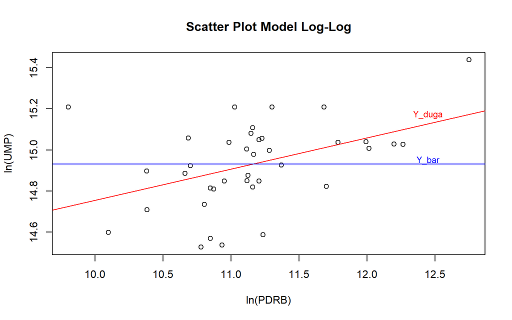

```r
y.bar <- mean(log_y)
plot(log_x,log_y,
     main = "Scatter Plot Model Log-Log",
     xlab = "ln(PDRB)",
     ylab = "ln(UMP)")
abline(model_log, col="red")
text(max(log_x) - 0.3, max(fitted(model_log)),
     "Y_duga", col = "red", cex = 0.8)
abline(h=y.bar, col="blue")
text(max(log_x) - 0.3, y.bar + 0.02,
     "Y_bar", col = "blue", cex = 0.8)
```

Dari scatter plot di atas, teramati adanya amatan yang menyimpang relatif terhadap nilai harapannya. Penyimpangan amatan dari nilai harapannya inilah yang disebut sebagai galat. Keragaman dari galat tiap amatan ini dapat diurai berdasarkan garis dugaan persamaan ($\hat{Y}$) dan garis rataan nilai resposnya ($\bar{Y}$). Penguraian keragaman ini dapat dituliskan sebagai Jumlah Kuadrat Regresi (JKR), Jumlah Kuadrat Galat (JKG), dan Jumlah Kuadrat Total (JKT) dengan perhitungan sebagai berikut.

$$\text{JKR} = \sum_{i=1}^{n} (\hat{y}_i -
\bar{y})^2 ; \text{JKG} = \sum_{i=1}^{n} (y_i - \hat{y})^2 ; \text{JKT}
= \sum_{i=1}^{n} (y_i - \bar{y})^2$$
Hubungan antara ketiganya dapat pula dituliskan sebagai berikut.

$$JKT = JKR + JKG$$
Nilai penguraian keragaman ini dapat diamati pula menggunakan fungsi anova pada bagian **Sum Sq (Jumlah Kuadrat)** seperti yang ditampilkan di bawah. Pada output sintaks di bawah, JKR model log bernilai 0.29777 dan JKG model log bernilai 1.28090.

```r
(anova.model_log <- anova(model_log))
```

|  | Df | Sum Sq | Mean Sq | F value | Pr(>F) |
| --- | --- | --- | --- | --- | --- |
| log_x | 1 | 0.297771 | 0.29777096 | 8.368934 | 0.006440302 |
| Residuals | 36 | 1.280898 | 0.03558051 | NA | NA |

$$\sigma^2_e = S_{e}^2= \text{KTG} =
\frac{\text{JKG}}{n-2}$$

```r
(KTG <- anova.model_log$`Mean Sq`[2])
```

```
## [1] 0.03558051
```

Dari nilai dugaan ragam galat di atas, dapat diduga pula nilai dugaan dari simpangan bakunya. Dugaan simpangan baku inilah yang disebut sebagai galat baku. Hubungan antara galat baku dan ragam galat dapat dituliskan sebagai berikut.

$$S_e = \sqrt{S_{e}^2}$$

Oleh karena simpangan baku merupakan akar kuadrat dari ragam, maka nilai dugaan galat baku model yang kita bentuk adalah $S_e = \sqrt{0.03558051} \approx 0.188628$

```r
(galat.baku <- sqrt(KTG))
```

```
## [1] 0.188628
```

# 4 Keragaman Dugaan Parameter

## 4.1 Dugaan Parameter $\beta_0$

```r
(b0 <- model_log$coefficients[[1]])
```

```
## [1] 13.2333
```

```r
(b1 <- model_log$coefficients[[2]])
```

```
## [1] 0.1521264
```

Selanjutnya kita dapat menghitung nilai ragam dan t-hitung dari dugaan parameter $β_0$ tersebut dengan perhitungan sebagai berikut.

$$\text{S}_{\hat{\beta_0}} = \sqrt{KTG
\left[\frac{1}{n} + \frac{\bar{X}^2}{\sum_{i=1}^{n}(X_i -
\bar{X})^2}\right]} ; t_{h} = \frac{\hat{\beta_0} -
\beta_0}{S_{\hat{\beta_0}}}$$
Nilai $\text{S}_{\hat{\beta_0}}$ dapat dihitung dengan sintaks sebagai berikut

```r
(se_b0 <- sqrt(KTG*(1/n+mean(log_x)^2/sum((log_x-mean(log_x))^2))))
```

```
## [1] 0.5897403
```

Jika dalam uji hipotesis kita ingin menguji apakah $\beta_0$, maka nilai th dapat dihitung sebagai berikut.

```r
uji <- 0
(t_b0 <- (b0 - uji)/se_b0)
```

```
## [1] 22.4392
```

```r
abs(qt(0.025, df = n-2))
```

```
## [1] 2.306004
```

## 4.2 Dugaan Parameter $\beta_1$

Sementara itu, ragam dan t-hitung dari dugaan parameter $\beta_1$ dapat diperoleh dari perhitungan berikut.

$$\text{S}_{\hat{\beta_1}} =
\sqrt{\frac{KTG}{\sum_{i=1}^{n}(x_i - \bar{x})^2}} ; t_{h} =
\frac{\hat{\beta_1} - \beta_1}{S_{\hat{\beta_1}}}$$

Nilai $\text{S}_{\hat{\beta_1}}$ dapat dihitung dengan sintaks sebagai berikut

```r
(se_b1 <- sqrt(KTG/sum((log_x-mean(log_x))^2)))
```

```
## [1] 0.05258592
```

Jika dalam uji hipotesis kita ingin menguji apakah $\beta_1 = 0$, maka nilai $t_h$ dapat dihitung sebagai berikut.

```r
uji <- 0
(t_b1 <- (b1 - uji)/se_b1)
```

```
## [1] 2.892911
```

```r
abs(qt(0.025, df = n-2))
```

```
## [1] 2.306004
```

# 5 Selang Kepercayaan Parameter

Secara umum, kita dapat memahami bahwa selang kepercayaan untuk $β_0$ dan $β_1$ terdiri atas batas bawah dan batas atas yang dapat dituliskan sebagai berikut.

$$\text{Selang Kepercayaan } \beta_0 :
\hat{\beta_0} \pm t_{\alpha/2, n-2} S_{\hat{\beta_0}}$$
$$\text{Selang Kepercayaan } \beta_1 :
\hat{\beta_1} \pm t_{\alpha/2, n-2} S_{\hat{\beta_1}}$$

Dengan menggunakan tingkat signifikansi $α = 0,05$, maka nilai $t_{α/2,n-2}$ dapat dihitung sebagai berikut.

```r
t_table <- abs(qt(0.025, df = n-2))
t_table
```

```
## [1] 2.306004
```

Selanjutnya, selang kepercayaan untuk parameter $β_0$ dan $β_1$ dapat dihitung sebagai berikut.

```r
# Selang kepercayaan beta0
lower_b0 <- b0 - t_table * se_b0
upper_b0 <- b0 + t_table * se_b0
cat("Selang kepercayaan beta0: [", lower_b0, ", ", upper_b0, "]\n")
```

```
## Selang kepercayaan beta0: [ 11.87336 ,  14.59324 ]
```

```r
# Selang kepercayaan beta1
lower_b1 <- b1 - t_table * se_b1
upper_b1 <- b1 + t_table * se_b1
cat("Selang kepercayaan beta1: [", lower_b1, ", ", upper_b1, "]\n")
```

```
## Selang kepercayaan beta1: [ 0.03086304 ,  0.2733897 ]
```

Sehigga dapat disimpulkan bahwa pada taraf signifikansi 5%, selang kepercayaan untuk parameter $β_0$ adalah [ 11.87336 , 14.59324 ] dan untuk parameter $β_1$ adalah [ 0.03086304 , 0.2733897 ].

# 6 Selang Kepercayaan

## 6.1 Bagi Nilai Rataan/Nilai Harapan Amatan

```r
amatan.diduga <- data.frame(x=10)
predict(model_log, amatan.diduga, interval = "confidence")
```

```
##         fit      lwr      upr
## 1  14.85907 14.77928 14.93886
## 2  14.93804 14.87576 15.00031
## 3  14.89933 14.83351 14.96515
## 4  15.06122 14.95061 15.17183
## 5  14.96305 14.89695 15.02914
## 6  14.94122 14.87872 15.00372
## 7  14.87692 14.80434 14.94950
## 8  14.88338 14.81305 14.95372
## 9  14.93088 14.86882 14.99294
## 10 15.05757 14.94907 15.16607
## 11 15.17282 14.99204 15.35361
## 12 14.89673 14.83028 14.96318
## 13 14.87297 14.79892 14.94703
## 14 14.88369 14.81345 14.95393
```

[output cut: 24 more lines]

```r
# di atas masih satuan aslinya (In(Y)), sehingga perlu di antilog
hasil_conf <- predict(model_log, amatan.diduga, interval = "confidence")
exp(hasil_conf) #antilog ke satuan rupiah
```

```
##        fit     lwr     upr
## 1  2839306 2621550 3075150
## 2  3072605 2887091 3270040
## 3  2955951 2767654 3157058
## 4  3475407 3111485 3881894
## 5  3150420 2948933 3365673
## 6  3082409 2895648 3281216
## 7  2890445 2688080 3108043
## 8  2909189 2711589 3121189
## 9  3050695 2867127 3246016
## 10 3462725 3106685 3859569
## 11 3885729 3243087 4655714
## 12 2948273 2758727 3150842
## 13 2879058 2673550 3100363
## 14 2910075 2712687 3121827
```

[output cut: 24 more lines]

## 6.2 Bagi Individu amatan

Secara umum, kita dapat memahami bahwa selang kepercayaan untuk $\hat{y}(s_i)$terdiri atas batas bawah dan batas atas yang dapat dituliskan sebagai berikut.

$$\hat{y}(x_i)\pm t_{\alpha/2, n-2} S_e
\sqrt{1+(\frac{1}{n} + \frac{(\ln{x_0} -
\overline{\ln{x}})}{\sum_{1=1}^n(\ln{x_0} -
\overline{\ln{x}})^2})}$$

```r
predict(model_log, amatan.diduga, interval = "prediction")
```

```
##         fit      lwr      upr
## 1  14.85907 14.46828 15.24986
## 2  14.93804 14.55045 15.32563
## 3  14.89933 14.51115 15.28751
## 4  15.06122 14.66300 15.45945
## 5  14.96305 14.57482 15.35127
## 6  14.94122 14.55359 15.32885
## 7  14.87692 14.48754 15.26630
## 8  14.88338 14.49442 15.27235
## 9  14.93088 14.54332 15.31844
## 10 15.05757 14.65992 15.45521
## 11 15.17282 14.74970 15.59594
## 12 14.89673 14.50845 15.28501
## 13 14.87297 14.48332 15.26263
## 14 14.88369 14.49474 15.27264
```

[output cut: 24 more lines]

```r
# di atas masih satuan aslinya (In(Y)), sehingga perlu di antilog
hasil_pred <- predict(model_log, amatan.diduga, interval = "prediction")
exp(hasil_pred) #antilog ke satuan rupiah
```

```
##        fit     lwr     upr
## 1  2839306 1920857 4196908
## 2  3072605 2085346 4527260
## 3  2955951 2005000 4357928
## 4  3475407 2333773 5175505
## 5  3150420 2136808 4644846
## 6  3082409 2091924 4541871
## 7  2890445 1958209 4266485
## 8  2909189 1971720 4292384
## 9  3050695 2070548 4494820
## 10 3462725 2326609 5153623
## 11 3885729 2545149 5932418
## 12 2948273 1999578 4347075
## 13 2879058 1949954 4250857
## 14 2910075 1972356 4293615
```

[output cut: 24 more lines]